# IR_Specialist_AbdallaElgharbawy

Abdalla Elgharbawy

2025-04-11

## Task Execution

### Step 1: Read Extracted CSV and Display Data

```r
families <- read.csv("families.csv", header = FALSE, sep = ",", quote = "\"", fill = TRUE)
colnames(families) <- c("FamilyName", "Description")
head(families)
```

```
##    FamilyName
## 1  FamilyName
## 2  Asteraceae
## 3   Liliaceae
## 4    Rosaceae
## 5 Orchidaceae
## 6    Fabaceae
##                                                           Description
## 1                                                         Description
## 2                                           Known as the daisy family
## 3 The lily family consists of flowering plants like lilies and tulips
## 4                                      The rose family includes roses
## 5                                   One of the largest plant families
## 6                                        Also known as the pea family
##                                                            NA
## 1
## 2                              this group includes sunflowers
## 3         known for their showy flowers and ornamental value.
## 4                                                strawberries
## 5  orchids are prized for their unique and intricate flowers.
## 6                              it includes legumes like beans
##                                                                    NA
## 1
## 2                                                             daisies
## 3
## 4  and apples. They are vital for their fruit and ornamental flowers.
## 5
## 6                                                                peas
##                                                                     NA
## 1
## 2  and asters. They are distinguished by their composite flower heads.
## 3
## 4
## 5
## 6                                                         and lentils.
```

### Step 2: Load Required Libraries

```r
library(readr)
library(textstem)
library(tm)
```

```r
library(stringr)
library(wordcloud)
library(tidytext)
library(tidyverse)
```

### Step 3: Text Preprocessing

```r
corpus <- VCorpus(VectorSource(families$Description))

preprocess_text <- function(corpus) {
  corpus <- tm_map(corpus, content_transformer(tolower))
  corpus <- tm_map(corpus, removePunctuation)
  corpus <- tm_map(corpus, removeWords, stopwords("english"))
  corpus <- tm_map(corpus, stripWhitespace)
  corpus <- tm_map(corpus, content_transformer(lemmatize_strings))
  return(corpus)
}

corpus <- preprocess_text(corpus)
```

### Step 4: Create TF-IDF Matrix

```r
tdm <- TermDocumentMatrix(corpus)
tdm_matrix <- as.matrix(tdm)
dtm_matrix <- t(tdm_matrix)

tf <- dtm_matrix / rowSums(dtm_matrix)
idf <- log(nrow(dtm_matrix) / colSums(dtm_matrix > 0))
tfidf <- tf %*% diag(idf)
tfidf_df <- as.data.frame(tfidf)
colnames(tfidf_df) <- colnames(dtm_matrix)

dim(tfidf_df)
```

```
## [1] 31 87
```

### Step 5: Sparsity Analysis

```r
total_elements <- nrow(tfidf_df) * ncol(tfidf_df)
non_zero_elements <- sum(tfidf_df != 0)
sparsity <- 1 - (non_zero_elements / total_elements)
cat("Sparsity of the TF-IDF matrix:", round(sparsity * 100, 2), "%\n")
```

```
## Sparsity of the TF-IDF matrix: 94.22 %
```

### Step 6: Cosine Similarity with Apocynaceae

```r
library(lsa)
apocynaceae_index <- which(families$FamilyName == "Apocynaceae")
apocynaceae_vector <- as.numeric(tfidf_df[apocynaceae_index, ])

similarities <- apply(tfidf_df, 1, function(x) cosine(apocynaceae_vector, as.numeric(x)))
similarity_df <- data.frame(FamilyName = families$FamilyName, cosinesimilarity = similarities)
similar_families <- similarity_df[order(-similarity_df$cosinesimilarity), ]
head(similar_families, 5)
```

```
##       FamilyName cosinesimilarity
## 26   Apocynaceae       1.00000000
## 24  Asparagaceae       0.03361275
## 28 Commelinaceae       0.03053402
## 27       Araceae       0.02552140
## 4       Rosaceae       0.02545915
```

### Step 7: Visualize Top 5 Most Similar Families

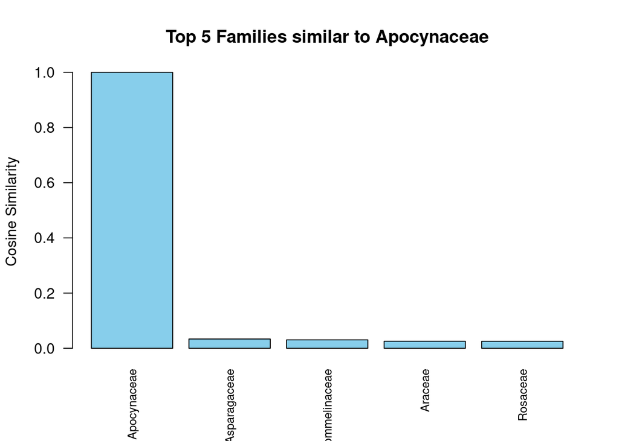

```r
top5 <- head(similar_families, 5)
barplot(top5$cosinesimilarity,
        names.arg = top5$FamilyName,
        main = "Top 5 Families similar to Apocynaceae",
        ylab = "Cosine Similarity",
        las = 2,
        col = "skyblue",
        cex.names = 0.8)
```

### Step 8: Get Top 10 TF-IDF Terms for Apocynaceae

```r
terms <- colnames(tfidf_df)
apocynaceae_terms <- as.numeric(tfidf_df[apocynaceae_index, ])
names(apocynaceae_terms) <- terms
top10_terms <- sort(apocynaceae_terms, decreasing = TRUE)[1:10]
print(top10_terms)
```

```
##     dogbane    milkweed  periwinkle     include       plant      family
##  0.57233120  0.57233120  0.57233120  0.14483964  0.11023308  0.01111523
##       adapt       agave agriculture        also
##  0.00000000  0.00000000  0.00000000  0.00000000
```

### Additional Insight: Cosine Similarity Heatmap

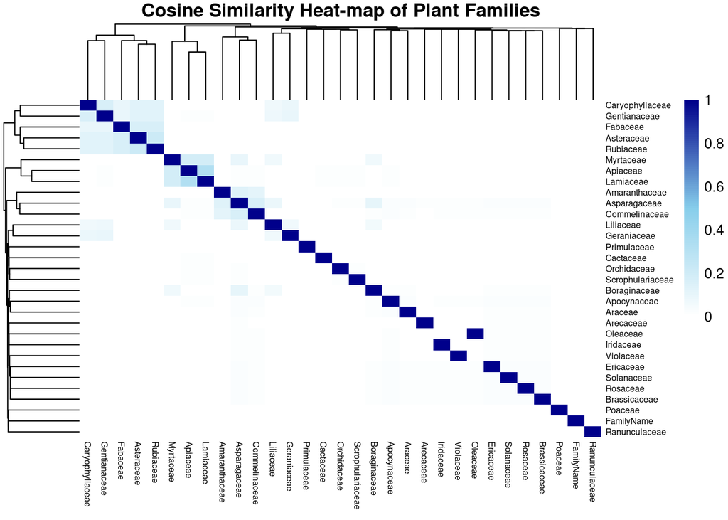

```r
library(text2vec)
similarity_matrix <- sim2(as.matrix(tfidf_df), method = "cosine", norm = "l2")
similarity_matrix <- round(similarity_matrix, 2)
rownames(similarity_matrix) <- families$FamilyName
colnames(similarity_matrix) <- families$FamilyName

library(pheatmap)
pheatmap(similarity_matrix,
         main = "Cosine Similarity Heat-map of Plant Families",
         fontsize_row = 6,
         fontsize_col = 6,
         color = colorRampPalette(c("White", "skyblue", "darkblue"))(100),
         border_color = NA)
```

## Assumptions and Challenges

The R package version compatibility became one of the main hurdles in this project. At first, I tried to carry on with the work on R Studio Desktop on my personal laptop, which had R version 4.1. Because of that, I ran into trouble installing and using the packages rmarkdown, knitr, and others that were required for the final rendering of the report into HTML format. Despite various attempts to install the dependencies, I could not knit the R Markdown file on that particular setup.

So, I opted for Posit Cloud, which is running the latest version of R Studio (version 4.4.3). This environment already contained the tools required for the analyses in this project and allowed me to install all packages free of version conflicts. Essentially, it eased the whole process, and I managed to produce the HTML report as required.

In addition, I assumed that the family descriptions extracted from the XML file were clean and properly formatted, which was vital for the correct calculation of TF-IDF scores and cosine similarity metrics. I have also taken the stance that lemmatization should suffice to reduce terms to their root forms without stemming.

## Conclusion

In this project, I demonstrated how text mining techniques can be applied to botanical family descriptions in order to show semantic relationships. In proceeding with the extracted dataset, I performed multiple text preprocessing techniques, including lowercasing, punctuation removal, stop-word filtering, and lemmatization, in order to prepare the data for meaningful analysis.

This would give further evidence of how non-natural language-derived descriptions can indeed be converted into numerical representational forms for quantitative similarity analysis to reveal even descriptive, non-structured relationships.